# A Tutorial on novelty and relevance metrics

**Author**: Bixuan Sun, Ph.D. (sunxx731@umn.edu)

**Full paper**: Sun, B., Kolesnikov, S., Goldstein, A., & Chan, G. (2021). A dynamic approach for identifying technological breakthroughs with an application in solar photovoltaics. Technological Forecasting and Social Change, 165, 120534.

## Overview

This is R tutorial on how to (1) extract relevant patents from PatentsView for analysis; (2) build and tune topic model; (3) calculate novelty and relevance metrics; (4) additional analyses using novelty and relevance mmtrics.

## Step 1: Download relavant files and select patent sample

Go to [PatentsView](https://www.patentsview.org/download/) and download the following files: (1) Data on granted patents: *patent.tsv*; (2) Current CPC classification data for all patents (applied retrospectively to all patents): *cpc_current.tsv*; (3) Detailed patent description text: *detail_desc_text.tsv* (provided upon request to contact@patentsview.org).

Next, import *cpc_current.tsv* and *patent.tsv* into RStudio and select relevant patents for future analysis.

```r
rm(list=ls())  #clear existing memory
library('data.table')
root.direct = c("D:/USPTO/") #set root directory

############# identify patents with Si related CPC classes #################
cpc = fread(paste(root.direct, 'cpc_current.tsv', sep="")) #import cpc data file
si.cpc = c("Y02E10/545","Y02E10/546","Y02E10/547", "Y02E10/548") #four specific CPC classes
si.patent.ids = cpc[subgroup_id %in% si.cpc, ]$patent_id #patent numbers of Si related patents
uniqueN(si.patent.ids) #number of Si related patents

pats = fread(paste(root.direct, 'patent.tsv', sep="")) #import patent data file
pats[,granted_year:=substr(date,1,4)] #create a variable of granted year
si.pv.pats = pats[(id %in% si.patent.ids) & (granted_year<=2016) & (granted_year>=1976)] #information on Si related patents granted between 1976 and 2016
nrow(si.pv.pats) #number of patents in the sample
head(si.pv.pats) #preview of patent information
write.csv(si.pv.pats, file =  paste(root.direct, 'silicon_patents.csv', sep=""), row.names = F) #export patent information as csv file
```

The datasets on patent full-texts are organized by year, therefore we need to import and screen for the si-related patent full-text by year. If there are patents with missing full-text from the database, we might need to manually add them to the dataset.

```r
################## import silicon PV patent text ##################
si.pv.text = fread(paste(root.direct, 'detail_desc_text/detail-desc-text-',1976,'.tsv', sep=""), nrows = 0)
for (n in 1976:2016){
  full.text = fread(paste(root.direct, 'detail_desc_text/detail-desc-text-',n,'.tsv', sep=""))
  si.pv.text.1 = full.text[patent_id %in% si.pats$id]

  si.pv.text = rbind(si.pv.text, si.pv.text.1)
}

write.csv(si.pv.text, file =  paste(root.direct, 'silicon_patents_full_text.csv', sep=""), row.names = F)

#Now check if there are missing patents in the full-text dataset
full.text.pat.ids = si.pv.text$patent_id
missing.ids = si.pats$id[!(si.pats$id %in% full.text.pat.ids)] #ids of the patents with missing full-text
```

## Step 2: Build topic model

In this step, we first construct the document-feature matrix for the topic model, then we use cross validation to determine the number of topics, finally we create the topic model and the resulting topic distribution matrix for the relevant patents.

```r
rm(list=ls())
library('data.table')
root.direct = c("E:/USPTO/")

si.pv.text = fread(paste(root.direct, 'silicon_patents_full_text.csv', sep="")) #import full texts
all.text = si.pv.text$detail_description_text #creating a vector of full texts
corpus = tolower(all.text) #convert all texts to lower case
```

### 2.1. Construct document-feature matrix

```r
library(quanteda)  #install package before use

tokens = tokens(corpus, what = "word",
                remove_numbers = F, remove_punct = T,
                remove_symbols = F, remove_hyphens = F)

# perform stemming on tokens
tokens = tokens_wordstem(tokens, language="english")

# delete list of stopwords
stopwords("english") #quanteda built in stopword
stoplist =fread(paste("E:/PATSTAT Data/", c("text_mining/stoplist.csv"), sep = ""))
stoplist = unique(stoplist$stopwords)

sw = unique(c(stopwords("english"),stoplist, "also","e.g", "can","includ","said","first","wherein","other","made","make", "later",  "copyright", "fig", "figur", "tabl", "description", "describ"))

tokens = tokens_select(tokens, sw,  selection = "remove")

# Create  bag-of-words mode
tokens.dfm = dfm(tokens, tolower = FALSE)

dfm = dfm_trim(tokens.dfm, min_termfreq = 10, termfreq_type="count") #set minimum term frequency to be 10
dim(dfm)

##################### delete additional stopwords #######################
terms = colnames(dfm)

### delete single letter and number
singles = terms[nchar(terms)==1] #44
terms = terms[nchar(terms)!=1]

#### delete two-letter
doubles = terms[nchar(terms)==2] #911
terms = terms[nchar(terms)!=2]

#### add some important two letter terms
chemical = fread(paste("E:/PATSTAT Data/", c("text_mining/chemicals.csv"), sep = ""))
A =c(singles, doubles)
append.1 = A[A %in% c(tolower(chemical$terms),  c("ac","dc","o2","o3","s2","h2","n2","i2","ii","iv","vi"))]

terms = c(terms, append.1)

#terms with numbers
C = terms[grep("[0-9][0-9][A-Za-z]",terms,perl = T)]
D = terms[grep("[A-Za-z][0-9][0-9]",terms,perl = T)] #terms with number

C[nchar(C)>=3 & nchar(C)<=9]
D[nchar(D)<=4 & nchar(D)>=3]

deleted.num = c(C[nchar(C)>=3 & nchar(C)<=9], D[nchar(D)<=4 & nchar(D)>=3])
terms = terms[!(terms %in% deleted.num)]

#delete all terms starting with purpose
terms = terms[!(terms %in% terms[grep("purpose:",terms,perl=T)])]

# remove terms with two-digit number or more
E = unique(c(terms[grep("[0-9][0-9]",terms,perl = T)],terms[grep("[0-9],[0-9]",terms,perl = T)]
             ,terms[grep("[0-9]-[0-9]",terms,perl = T)], terms[grep("[0-9]\\.[0-9]",terms,perl = T)]))
E[grep("[A-Za-z]",E,perl = T)]
terms = terms[!(terms %in% E[-grep("[A-Za-z]",E,perl = T)])] #keep the ones with letters


# remove all units pf distance
G = c("0.1m",
      terms[grep("[0-9]mm",terms,perl = T)],
      terms[grep("[0-9]mum",terms,perl = T)],
      terms[grep("[0-9]mol",terms,perl = T)],
      terms[grep("[0-9]cm",terms,perl = T)],
      terms[grep("[0-9]nm",terms,perl = T)],
      terms[grep("[0-9]æ¼ã¸²",terms,perl = T)],
      terms[grep("[0-9]angstrom",terms,perl = T)])

terms = terms[!(terms %in% G)]

## trim the matrix
dfm = dfm[,terms]
dim(dfm)

save(dfm, file = paste(root.direct,c("dfm_min10_si_pv_full_text.Rdata"), sep=""))  #export the document-feature matrix
```

### 2.2. Cross validation to determine the number of topics

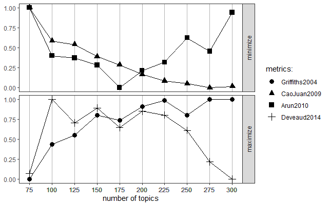

Figure 1. Cross validation on the number of topics

```r
#install and import packages
library("topicmodels")
library("ggplot2")
library("scales")
library("ldatuning")
load(paste(root.direct,c("dfm_min10_si_pv_full_text.Rdata"), sep="")) #import the saved document-feature matrix

set.seed(123)

dfm = dfm[which(rowSums(dfm) > 0),] #delete rows with zeros
dtm = convert(dfm,to="topicmodels") #need to convert to document term matrix which can be used by topicmodels package
dim(dtm)

######## cross-validation, different numbers of topics ############
result <- FindTopicsNumber(
  dtm,
  topics = c(75, 100, 125, 150, 175, 200, 225, 250, 275, 300),
  metrics = c("Griffiths2004", "CaoJuan2009", "Arun2010", "Deveaud2014"),
  method = "Gibbs",
  control = list(seed = 77),
  mc.cores = 2L,
  verbose = TRUE
)

FindTopicsNumber_plot(result) #inspect graphic output to determine the optimal number of topics
```

### 2.3. Build LDA topic model and calculate topic distribution matrix

```r
library("topicmodels")
library("tidytext")
library("tm")

######################### fit LDA model #################################
dfm = dfm[which(rowSums(dfm) > 0),] #delete rows with zeros
dtm = convert(dfm,to="topicmodels") #need to convert to document term matrix which can be used by topicmodels package
dim(dtm) # 3126 10399

lda.model = LDA(dtm,k = 200, control = list(seed = 123),alpha = 0.1, beta = 0.01 , verbose=1)
save(lda.model, file = paste(root.direct,c("lda_si_pv_full_text_200_topics_min10.RDS"), sep=""))


################# calculate topic distribution matrix ####################
lda.matrix = posterior(lda.model,dfm)$topics
dim(lda.matrix)
rownames(lda.matrix) = si.pv.text$patent_id #replace the matrix row names with patent numbers

save(lda.matrix, file = paste(root.direct,c("topic_dist_si_pv_full_text_200_topics_min10.Rdata"), sep=""))
```

## Step 3: Calculate novelty and relevance metrics

### 3.1. Annual field centroids

```r
rm(list=ls())
library('data.table')
library('ggplot2')
root.direct = c("E:/USPTO/")
si.pv.pats = fread(paste(root.direct, 'silicon_patents.csv', sep="")) #import si patent information from step 1
load(paste(root.direct,c("topic_dist_si_pv_full_text_200_topics_min10.Rdata"), sep="")) #load lda.matrix from step 2.3

####### write a function calculating the average topic probablities for the 200 topics, input: year
topic.dist = function(n){
  ids = si.pv.pats[granted_year == n]$id
  topic.dist = lda.matrix[as.character(ids),]

  avg.topic = data.table(colSums(topic.dist)/nrow(topic.dist))
  avg.topic[,topic:=seq(1,200,1)]
  setnames(avg.topic,"V1","avg_prob")

  return(avg.topic)
}

avg.topic = topic.dist(1990) #calculate the average topic distribution among patents granted in 1990

###### Plot the top 10 topics of the 1990 centroid
ggplot(avg.topic[order(-avg_prob)][1:10], aes( reorder(topic, avg_prob), avg_prob)) +
  geom_col(show.legend = FALSE) +
  labs(y=c("topics"),x=c("average probablity"), title=paste("Average topic distribution", n, sep = ",")) +
  ylim(0,0.2)+ coord_flip()+theme_gray()

###### create a dataset on average topic distribution from 1977 to 2016
centroids = topic.dist(1976)
centroids[,year:=1976]
for (n in 1977:2016){
  centroids.1 = topic.dist(n)
  centroids.1[,year:=n]
  centroids = rbind(centroids,centroids.1)
}
write.csv(centroids, file = paste(root.direct,c("centriods_si_pv_full_text_200_topics.csv"),sep = ""), row.names = F)
```

### 3.2. Calculate novelty and relevance metrics

Write a function *distance.function(n)* where *n* is the granted year of the patents to be evaluated.

```r
centroids = fread(paste(root.direct,c("centriods_si_pv_full_text_200_topics.csv"),sep = ""))

distance.function = function(j){
  n = j-1 #begining year centroid

  distance.dt.1 = data.table(between.pats=integer(),relevance=numeric(),novelty=numeric(),ending_centroid_yr=integer(), granted_year=integer())

  # 20 ending centroids
  for (m in (j+1):(j+20)){
    from.node = centroids[year==n]$avg_prob #begining centroid
    to.node = centroids[year==m]$avg_prob  #ending centroid
    MP.vector = to.node-from.node
    MP.dist = dist(rbind(as.vector(from.node),as.vector(to.node)))

    between.pats = si.pv.pats[granted_year==j,]$id
    between.pats = between.pats[as.character(between.pats) %in% row.names(lda.matrix)]

    between.pats.topics = lda.matrix[as.character(between.pats),]

    distance.dt = data.table(between.pats)

    for (i in 1:length(between.pats)){
      begin.cited.vector = lda.matrix[as.character(between.pats[i]),] - from.node

      if (sum(abs(begin.cited.vector))!=0){
        cosine = sum(MP.vector*begin.cited.vector)/(sqrt(sum(MP.vector*MP.vector)) * sqrt(sum(begin.cited.vector*begin.cited.vector)))
        sine = sqrt(1-cosine^2)

        dist.begin.cited = dist(rbind(as.vector(from.node),as.vector(lda.matrix[as.character(between.pats[i]),])))

        distance.dt[i,relevance := (cosine*dist.begin.cited)]
        distance.dt[i,novelty := (sine*dist.begin.cited)]

      } else{
        distance.dt[i,relevance := 0]
        distance.dt[i,novelty := 0]

      }

    }

    distance.dt[,ending_centroid_yr:=m]
    distance.dt[,granted_year:=j]

    distance.dt[,relevance:=as.numeric(relevance)]
    distance.dt[,novelty:=as.numeric(novelty)]

    distance.dt.1 = rbind(distance.dt.1,distance.dt)
  }
  setnames(distance.dt.1,"between.pats","id")


  distance.dt.1 = distance.dt.1[order(id)]
  distance.dt.1[,time_trend:=ending_centroid_yr-granted_year]

  return(distance.dt.1)

}

## example: novelty and relevance metrics of patents granted in 1990
j=1990
patent.distance = distance.function(j)
head(patent.distance)
```

### 3.3. Calculate slopes of novelty and relevance for each patent

Create a dataset that includes the changes/slopes of novelty and relevance values, initial novelty and relevance values of each patent in the study period. This dataset can be used for further qualitative validations.

```r
slope.dt.1 = data.table(id=as.character(),granted_year=as.integer(),initial_novelty=as.numeric(),initial_novelty_percentile=numeric(),
                        initial_relevance=as.numeric(),initial_relevance_percentile=numeric(),
                        novelty_slope=as.numeric(),relevance_slope=as.numeric(),
                        novelty_slope_first10=numeric(), relevance_slope_first10=numeric(),
                        novelty_slope_last10=numeric(), relevance_slope_last10=numeric())

for (k in 1977:1996){
  patent.distance = distance.function(k)
  between.ids = unique(patent.distance$id)

  #### calculate slope of novelty and relevance for each patent, between 1995 and 2005 #######
  slope.dt = data.table(between.ids)
  setnames(slope.dt,"id")

  slope.dt[,granted_year:=k]

  initial.novelty.vec = patent.distance[time_trend==1]$novelty
  initial.relevance.vec = patent.distance[time_trend==1]$relevance


  for (x in 1:length(between.ids)){
    slope.dt[id==between.ids[x],initial_novelty:=100*patent.distance[id==between.ids[x] & time_trend==1]$novelty]
    slope.dt[id==between.ids[x],initial_novelty_percentile:=length(initial.novelty.vec[initial.novelty.vec<patent.distance[id==between.ids[x] & time_trend==1]$novelty])/length(initial.novelty.vec)]

    slope.dt[id==between.ids[x],initial_relevance:=100*patent.distance[id==between.ids[x] & time_trend==1]$relevance]
    slope.dt[id==between.ids[x],initial_relevance_percentile:=length(initial.relevance.vec[initial.relevance.vec<patent.distance[id==between.ids[x] & time_trend==1]$relevance])/length(initial.relevance.vec)]



    slope.dt[id==between.ids[x],novelty_slope:=coef(lm((100*novelty) ~ time_trend,data = patent.distance[id==between.ids[x]]))[2]]
    slope.dt[id==between.ids[x],relevance_slope:=coef(lm((100*relevance) ~ time_trend,data = patent.distance[id==between.ids[x]]))[2]]

    slope.dt[id==between.ids[x],novelty_slope_first10:=coef(lm((100*novelty) ~ time_trend,data = patent.distance[id==between.ids[x]][1:10]))[2]]
    slope.dt[id==between.ids[x],relevance_slope_first10:=coef(lm((100*relevance) ~ time_trend,data = patent.distance[id==between.ids[x]][1:10]))[2]]

    slope.dt[id==between.ids[x],novelty_slope_last10:=coef(lm((100*novelty) ~ time_trend,data = patent.distance[id==between.ids[x]][10:20]))[2]]
    slope.dt[id==between.ids[x],relevance_slope_last10:=coef(lm((100*relevance) ~ time_trend,data = patent.distance[id==between.ids[x]][10:20]))[2]]

  }

  slope.dt.1 = rbind(slope.dt.1,slope.dt)
}

slope.dt.1
write.csv(slope.dt.1, file = paste(root.direct,c("slope_1977-1996_full_text_200_topics.csv"),sep = ""), row.names = F)
```

## Additional quantitative analysis

### (1) Plot the novelty and relevance values of known breakthrough patents

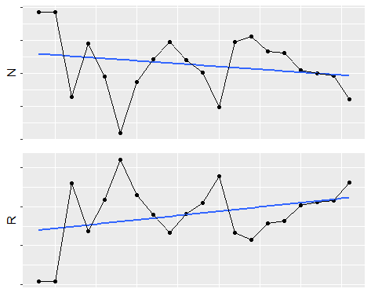

Figure 2. Novelty and relevance plot of patent US4086102 with linear trend lines

```r
library('data.table')
library("ggplot2")

slope.dt.1 = fread(paste(root.direct,c("slope_1977-1996_full_text_200_topics.csv"),sep = "")) #import dataset created in section 3.3.

pat.id = 4086102 #a breakthrough patent from Nemet & Husmann (2012)
patent.distance.1 = distance.function(as.numeric(silicon.pv.pats[id==pat.id]$granted_year))  #distance.function created in section 3.2.

{nov.1 = ggplot(patent.distance.1[id==pat.id], aes(x=ending_centroid_yr, y=novelty*100)) + geom_point(shape=16) + geom_smooth(method=lm, se=F) +
    geom_line() + labs(y=c("N")) +   theme(axis.title.x=element_blank(),
                           axis.text.x=element_blank(), axis.text.y=element_blank(),
                           axis.ticks.x=element_blank())

rel.1 = ggplot(patent.distance.1[id==pat.id], aes(x=ending_centroid_yr, y=relevance*100)) + geom_point(shape=16) + geom_smooth(method=lm, se=F) +
    geom_line() +labs(y=c("R")) +   theme(axis.title.x=element_blank(),
                           axis.text.x=element_blank(),axis.text.y=element_blank(),
                           axis.ticks.x=element_blank())

plot_grid(nov.1, rel.1,hjust = 0, vjust = 1,align = "h", ncol=1,nrow=2, scale = c(1., 1.))}
```

### (2) Plot two linear trends and a quadratic trend

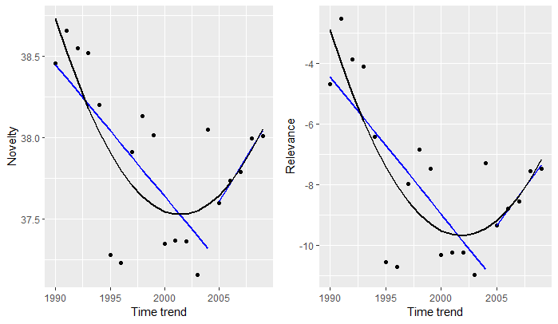

Figure 3. Novelty and relevance plot of patent US4843451 with linear and quadratic trend lines

```r
pat.id=4843451
patent.distance = distance.function(as.numeric(silicon.pv.pats[id==pat.id]$granted_year))

candidate = patent.distance[id==pat.id]
candidate[time_trend<=15,horizon:="one"]
candidate[time_trend>15,horizon:="two"]

# novelty
candidate[horizon=="one",linear.novel.fitted:=lm(novelty ~ time_trend, candidate[horizon=="one"])$fitted.values]
candidate[horizon=="two",linear.novel.fitted:=lm(novelty ~ time_trend, candidate[horizon=="two"])$fitted.values]
candidate[,poly.novel.fitted:=lm(novelty ~ poly(time_trend,2), candidate)$fitted.values]
summary(lm(100*novelty ~ poly(time_trend,2, raw = TRUE), candidate))

coefs = coefficients(lm(100*novelty ~ poly(time_trend,2, raw = TRUE), candidate))
-coefs[2]/(2*coefs[3])

# relevance
candidate[horizon=="one",linear.rel.fitted:=lm(relevance ~ time_trend, candidate[horizon=="one"])$fitted.values]
candidate[horizon=="two",linear.rel.fitted:=lm(relevance ~ time_trend, candidate[horizon=="two"])$fitted.values]
candidate[,poly.rel.fitted:=lm(relevance ~ poly(time_trend,2), candidate)$fitted.values]
summary(lm(100*relevance ~ poly(time_trend,2, raw = T), candidate))

coefs = coefficients(lm(100*relevance ~ poly(time_trend,2, raw = TRUE), candidate))
-coefs[2]/(2*coefs[3])

{nov = ggplot(candidate, aes(x=ending_centroid_yr, y=novelty*100)) +
    geom_point(shape=16) +
    geom_line(aes(x=ending_centroid_yr, y=linear.novel.fitted*100, color=horizon),size=1, linetype="solid")+
    geom_line(aes(x=ending_centroid_yr, y=poly.novel.fitted*100),size=1, color = "black")+
    labs(x=c("Time trend"),y=c("Novelty"))  + scale_color_manual(values=c("blue", "blue")) +
    theme_grey() + theme(legend.position="none")

  #plot relevance
  rel =  ggplot(candidate, aes(x=ending_centroid_yr, y=relevance*100)) +
    geom_point(shape=16) +
    geom_line(aes(x=ending_centroid_yr, y=linear.rel.fitted*100, color=horizon),size=1)+
    geom_line(aes(x=ending_centroid_yr, y=poly.rel.fitted*100),size=1, color = "black")+
    labs(x=c("Time trend"),y=c("Relevance"))  + scale_color_manual(values=c("blue", "blue")) +
    theme_grey() + theme(legend.position="none")

  plot_grid(nov, rel, hjust = 0, vjust = 1,align = "h", ncol=2, scale = c(1., 1.))

}
```